# Breast Cancer

# Overview

Breast cancer sub-type

[The Cancer Genome Atlas (TCGA)](https://www.cancer.gov/about-nci/organization/ccg/research/structural-genomics/tcga), a landmark cancer genomics program by National Cancer Institute (NCI), molecularly characterized over 20,000 primary cancer and matched normal samples spanning 33 cancer types. The genome data is open to public from the [Genomic Data Commons Data Portal (GDC)](https://portal.gdc.cancer.gov/).

Focus is on 4 sub-types of breast cancer (BRCA): basal-like (basal), Luminal A-like (lumA), Luminal B-like (lumB), HER2-enriched. The sub-type is based on PAM50, a clinical-grade luminal-basal classifier.

- Luminal A cancers are low-grade, tend to grow slowly and have the best prognosis.
- Luminal B cancers generally grow slightly faster than luminal A cancers and their prognosis is slightly worse.
- HER2-enriched cancers tend to grow faster than luminal cancers and can have a worse prognosis, but they are often successfully treated with targeted therapies aimed at the HER2 protein.
- Basal-like breast cancers or triple negative breast cancers do not have the three receptors that the other sub-types have so have fewer treatment options.

208 in Basal, 91 in Her2, 628 in lumA, 233 in lumB.

```
##   Group.1   x
## 1   Basal 208
## 2    Her2  91
## 3    LumA 628
## 4    LumB 233
```

Randomly picking 5 genes and plot the histogram by each sub-type.

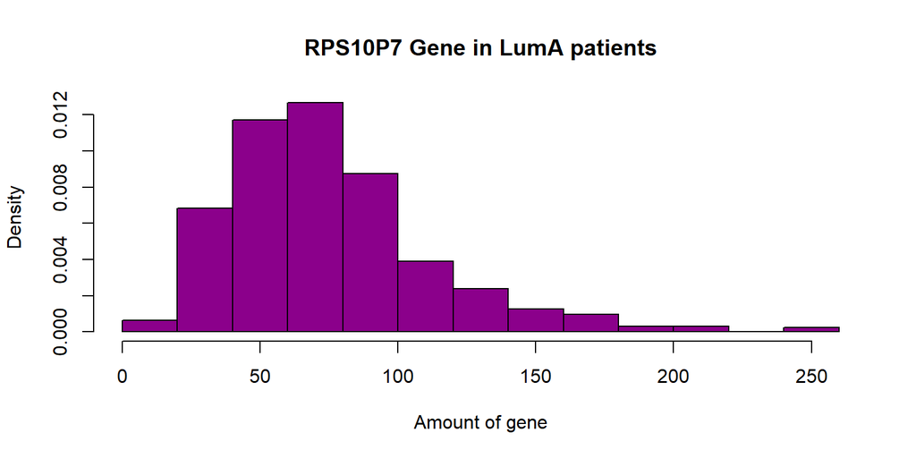

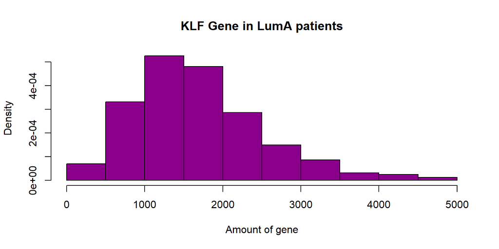

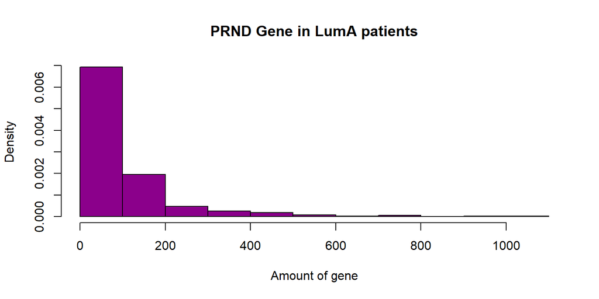

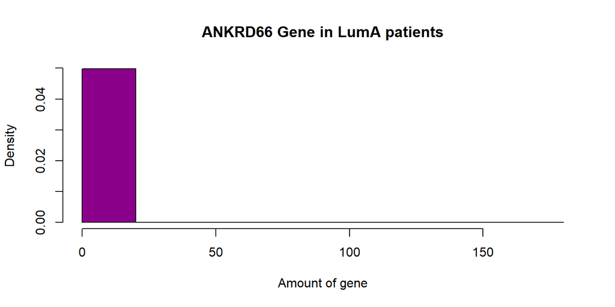

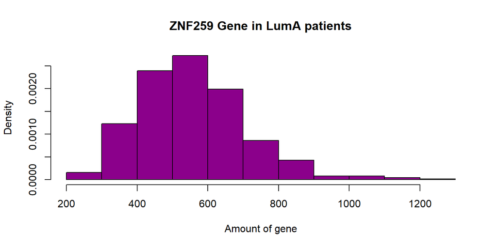

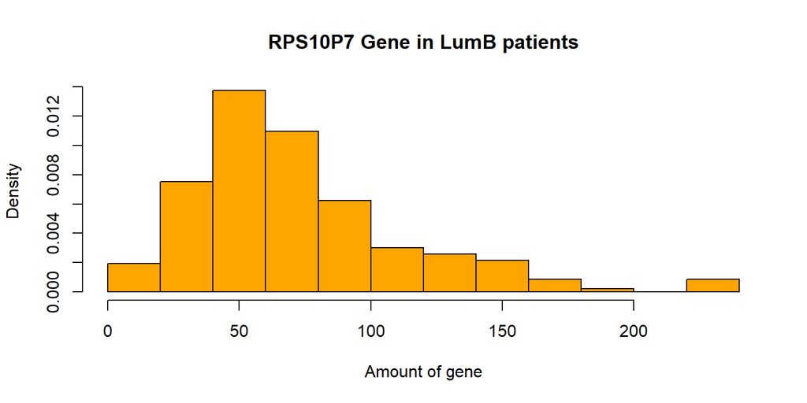

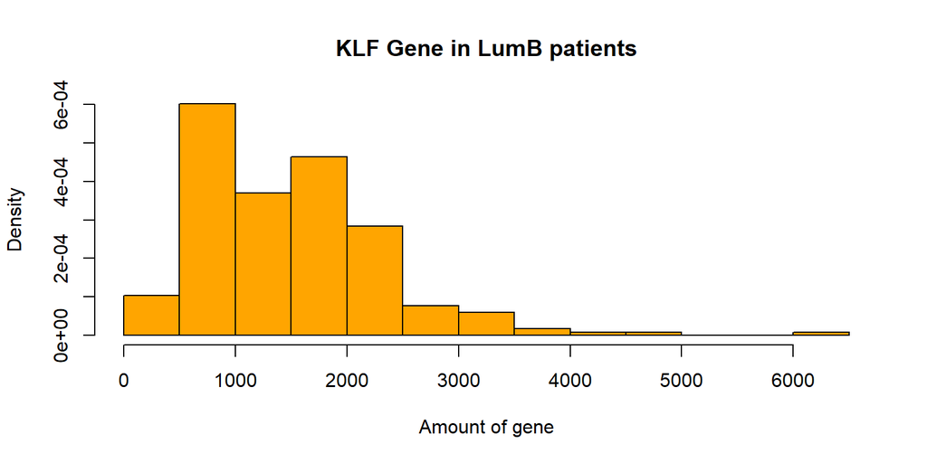

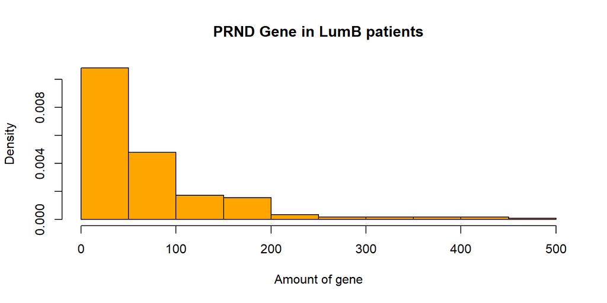

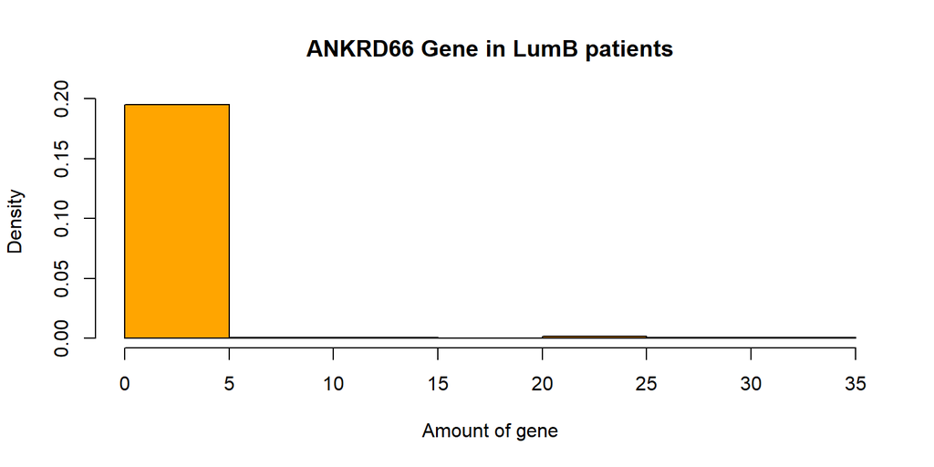

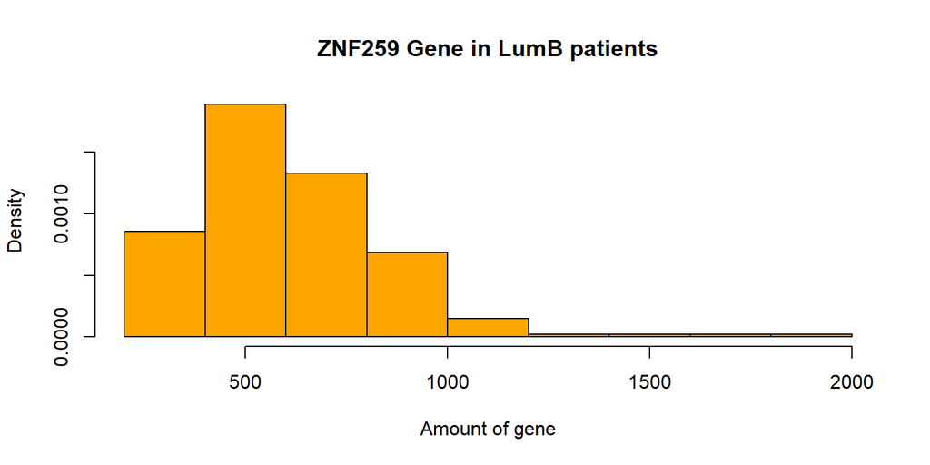

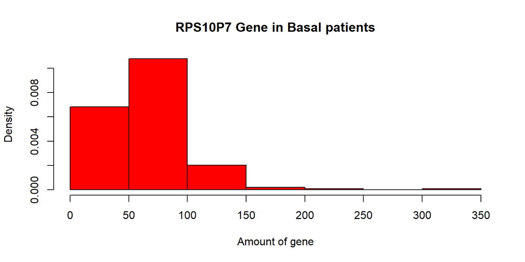

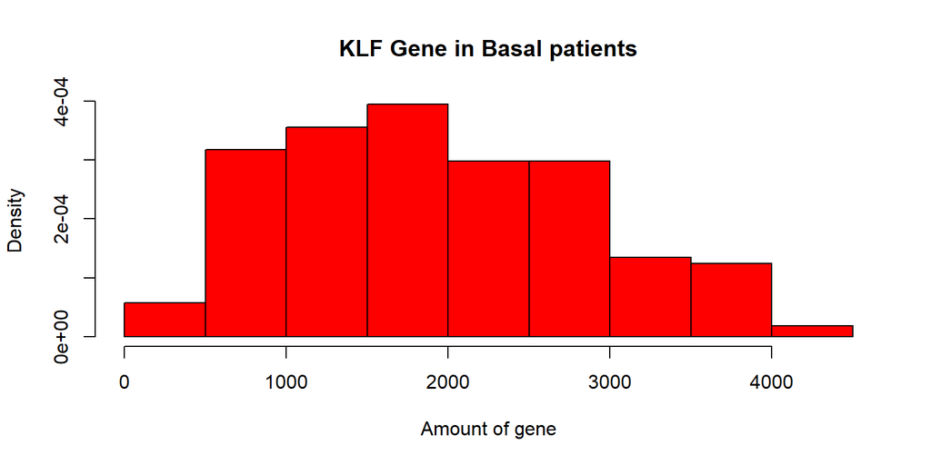

[8 more figures not shown]

c) Remove gene with zero count and no variability. Then apply logarithmic transform.

[output not shown]

2. Spectrum clustering: to scale or not to scale?

We should use 4 principal components by the elbow rule.

```
## [1] "d"     "u"     "v"     "iter"  "mprod"
```

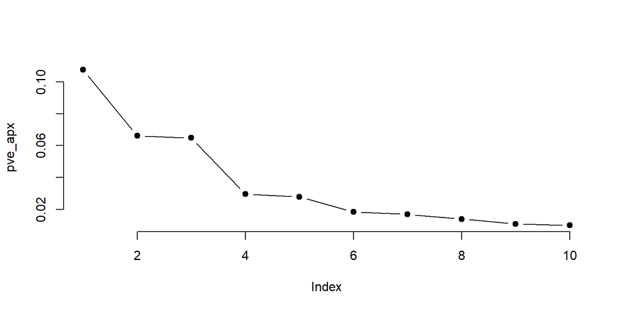

**Centered and Scaled**

**Centered and unscaled**

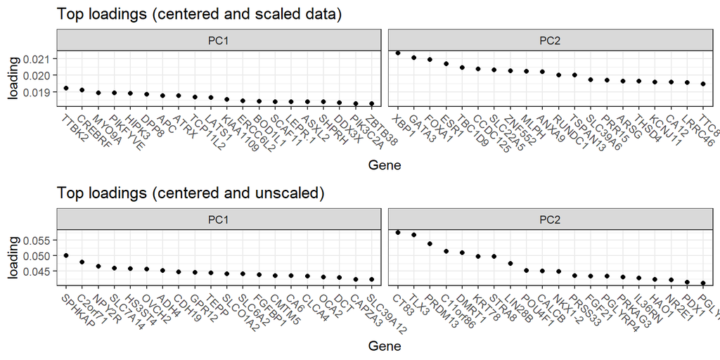

Spectrum clustering: center but do not scale the data

Use the first 4 PCs of the centered and unscaled data and apply kmeans. Finding a reasonable number of clusters using within sum of squared with the elbow rule.

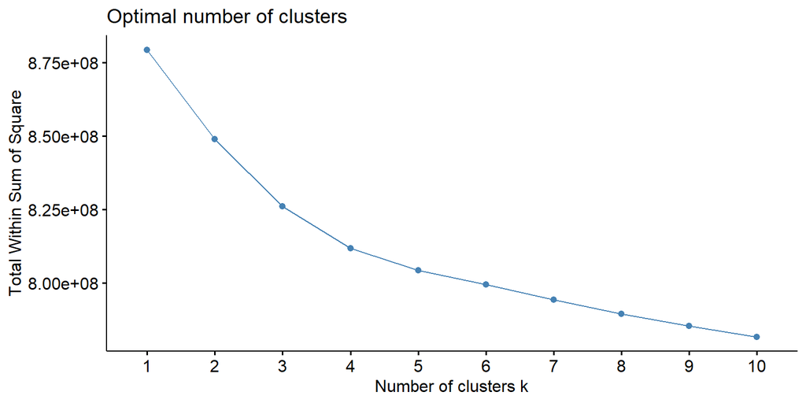

Choosing an optimal cluster number and applying kmeans.

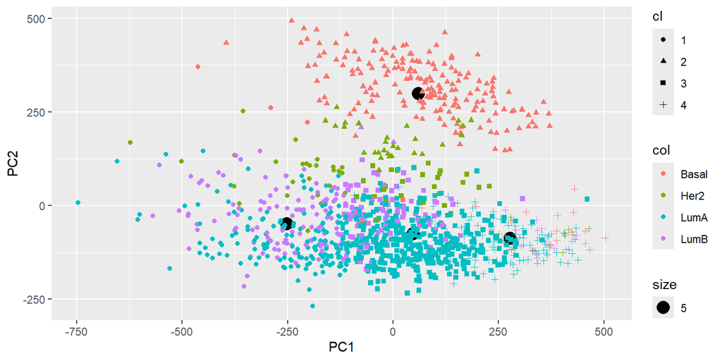

No evidence that using PCs help in clustering.

```
##
## brca_subtype   1   2   3   4
##        Basal  17 187   3   1
##        Her2    9  16  23  43
##        LumA   86   0 147 395
##        LumB   22   2 105 104
```

```
##
## brca_subtype   1   2   3   4
##        Basal   3 187   1  17
##        Her2   27  28  27   9
##        LumA  161   0 376  91
##        LumB  110   2  99  22
```

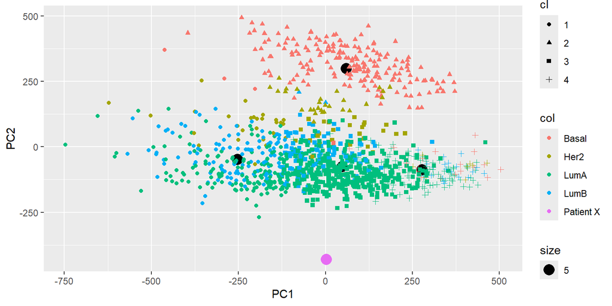